# Analysis of ETI Data

### Growth Protocol for human cells

Human primary airway epithelial cells were grown in BronchiaLife basal medium (Lifeline Cell Technology, Frederick, MD, Cat. #LM-0007) supplemented with the BronchiaLife B/T LifeFactors Kit (Lifeline Cell Technology, Cat. #LS-1047) and penicillin (10,000 U/mL) and streptomycin (10,000 μg/mL) (Sigma-Aldrich, Cat. #P4333). 500,000 cells were seeded on 24-mm permeable supports (Corning, Corning, NY, Cat. #3407), coated with Collagen type IV (Sigma-Aldrich, Cat #C-7521) and grown in an air-liquid interface media (University of North Carolina, Chapel Hill, NC) at 37°C for 3 to 4 weeks to establish polarized monolayers.

### Growth Protocol for Bacteria

Pseudomonas aeruginosa strain PA14 was grown in artificial sputum medium (ASM) then centrifuged, washed, and resuspended in fresh ASM before measuring the optical density at 600 nm (OD600) to determine number of bacteria.

### Outer Membrane Vesicles

Outer membrane vesicles (bEVs) were prepared by centrifuging cultures at 2,800 g and 4 degrees C for 1 h to pellet bacteria. Supernatants were filtered twice through 0.45 μm PVDF membrane filters (Millipore, Billerica, MA) then concentrated to approximately 200 μL by centrifugation in 30 K Amicon filters (Millipore, Billerica, MA) at 2,800 g and 4 C. Concentrates were resuspended in buffer (20 mM HEPES, 500 mM NaCl, pH 7.4) and ultracentrifuged 2 h at 39,000 g and 4 C to pellet bEVs, which were resuspended in 60% OptiPrep Density Gradient Medium (Sigma-Aldrich, Cat. No. D1556) and layered with 40%, 35%, 30%, and 20% OptiPrep diluted in buffer. bEVs in OptiPrep layers were ultacentrifuged for 16 h at 100,000 g and 4 C. Fractions (500 μL) were taken from the top of the gradient, with bEVs residing in fractions 2–3, corresponding to 25% OptiPrep. The purified bEVs were quantified by nanoparticle tracking analysis (NTA, NanoSight NS300, Malvern Panalytical Ltd, Malvern, UK)

### Wild type cell exposures

Polarized human primary airway epithelial cells from donors with wild type CFTR were conditionally exposed to either Pseudomonas aeruginosa strain PA14 at a multiplicity of infection of 20:1(~2x10^7 bacteria) or 2e10 outer membrane vesicles (bEV) isolated from Pseudomonas aeruginosa strain PA14 for 6 hours, or media only as a control.

### CF cell expoosures

Polarized human primary airway epithelial cells from donors homozygous for the delta F 508 CFTR mutation were conditionally exposed to elexacaftor (3 micromolar) tezacaftor (3 micromolar) ivacaftor (10 nanomolar) dissolved in DMSO or DMSO as a control for 48 hours and then conditionally exposed to either Pseudomonas aeruginosa strain PA14 at a multiplicity of infection of 20:1 (~2x10^7 bacteria) or 2e10 outer membrane vesicles (bEV) isolated from Pseudomonas aeruginosa strain PA14 for 6 hours, or media only as a control.

### Read in aligned reads

```r
library(readxl)

d <- read.delim(file = "../featurecounts/featurecounts.readcounts.ann.tsv", sep = "\t", comment.char = "#")

AnnotInfo <- d[,1:2]
Raw <- as.matrix(d[, grep("BS", colnames(d))])
```

### Read in, and interpret, meta-data

The original sample annotation is a little hard to follow. For example. it includes “Control OMVs” which does not (one hopes) contain outer membrane vesicles, but rather media that was processed the same way one would process outer membrane vesicles – lots of centrifugation. We call this special blank the process control, or “PC” for short.

```r
MetaRaw <- read_excel("../metadata.xlsx", skip = 2)
RawMetaFields <- strsplit(MetaRaw$`External Name`, split = " ")


# Process meta data
Meta <- data.frame("Sample" = MetaRaw$Id, "Desc" = MetaRaw$`External Name`)
rownames(Meta) <- Meta$Sample

Meta$Donor <- sapply(RawMetaFields, "[[", 2)
Meta$Geno <- sapply(RawMetaFields, "[[", 1)

Meta$Pathogen <- sapply(RawMetaFields, function (f){
  if (f[1] == "WT" & length (f)  == 3){
    f[3]
  } else if (f[1] == "WT" & length (f)  == 4 & f[3] == "Control"){
    "PC"
  } else if (f[1] == "WT" & length (f)  == 4 & f[3] == "PA14") {
    "OMV"
  } else if (f[1] == "dF" & length (f)  == 4) {
    f[3]
  } else if (f[1] == "dF" & length (f)  == 5 & f[3] == "Control"){
   "PC"
  } else if (f[1] == "dF" & length (f)  == 5 & f[3] == "PA14") {
   "OMV"
  } else{
    paste(f, collapse = '.')
  }
})

Meta$Rx <- NULL

Meta$Rx <-sapply(RawMetaFields, function (f){
  if (f[1] == "dF"){
    f[length(f)]
  } else {
    "Control"
  }
})

write.csv(Meta, file = "Meta.csv")
```

### Subset the data for ETI only

Only CF cells were exposed to ETI, and for this paper, we are only concerned with the simple question of what ETI does (if anything) to gene expression. Looking at things this way can reduce power (though it might not) because each of 5 donors will be observed in only two conditions: with and without ETI.

```r
ETI_Samples <- Meta[Meta$Geno == "dF" & Meta$Pathogen == "Control", "Sample" ]

ETI_counts <- as.matrix(Raw[, colnames(Raw) %in% ETI_Samples])

ETI_meta <- Meta[colnames(ETI_counts), ]
```

### Alligned read counts per sample look ok

This figure might appear as supplemental data. Certainly, we might cite the range of aligned reads (~6 to 13 million)

```r
range(colSums(ETI_counts))/1000000
```

```
[1]  5.526959 13.267132
```

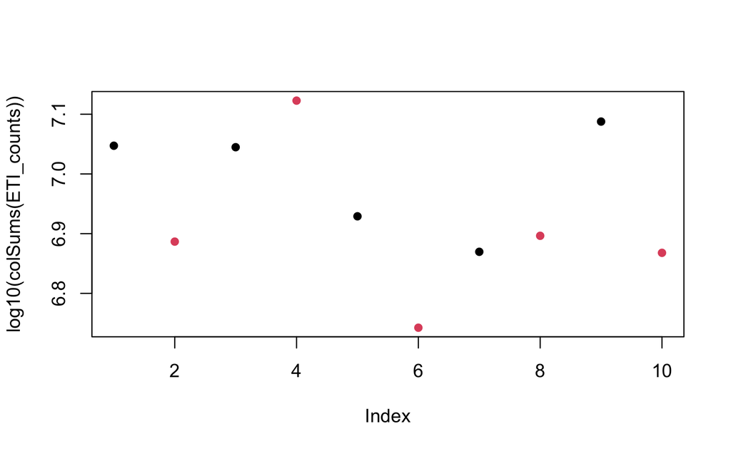

```r
plot(log10(colSums(ETI_counts)), col = as.factor(ETI_meta$Rx), pch = 16)
```

### Normalize data in edgeR

```r
library(edgeR)

DGE.ETI <- DGEList(counts = ETI_counts, remove.zeros = TRUE, genes = AnnotInfo)
```

```
Removing 35603 rows with all zero counts
```

```r
design.ETI <- model.matrix(~ ETI_meta$Donor + ETI_meta$Rx)

keep <- filterByExpr(DGE.ETI, design.ETI, min.count = 10, min.total.count = 15)

DGE.ETI <- DGE.ETI[keep, ] # keep only well-expressed genes

DGE.ETI <- calcNormFactors(DGE.ETI) # adding information to DGEList object!

DGE.ETI$samples # normalization factors have been added
```

|  | group | lib.size | norm.factors |
| --- | --- | --- | --- |
| BS021 | 1 | 11149618 | 0.8560791 |
| BS023 | 1 | 7703008 | 0.8871853 |
| BS029 | 1 | 11086315 | 1.0945971 |
| BS031 | 1 | 13267132 | 1.1063471 |
| BS037 | 1 | 8492851 | 1.0922603 |
| BS039 | 1 | 5526959 | 1.0432980 |
| BS045 | 1 | 7406370 | 0.9906043 |
| BS047 | 1 | 7877957 | 0.9422411 |
| BS053 | 1 | 12237669 | 1.0352010 |
| BS055 | 1 | 7377252 | 0.9874262 |

```r
DGE.ETI <- estimateGLMCommonDisp(DGE.ETI, design.ETI, verbose = TRUE) # Disp = 0.10885 , BCV = 0.3299
```

```
Disp = 0.10885 , BCV = 0.3299
```

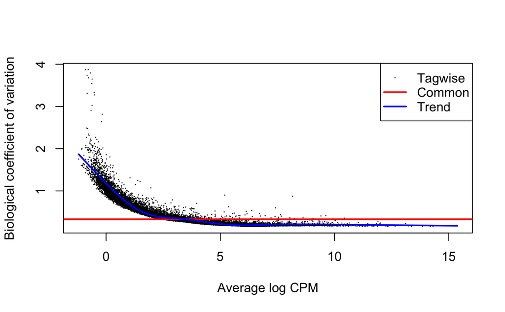

```r
DGE.ETI <- estimateGLMTrendedDisp(DGE.ETI, design.ETI )
DGE.ETI <- estimateGLMTagwiseDisp(DGE.ETI, design.ETI )

plotBCV(DGE.ETI)
```

```r
CPM.ETI <- as.data.frame(cpm(DGE.ETI, normalized.lib.sizes = TRUE, log = TRUE))

CPM.ETI.Annot <- cbind(DGE.ETI@.Data[[3]]$Ensembl.ID, DGE.ETI@.Data[[3]]$Gene.Name, CPM.ETI)

colnames(CPM.ETI.Annot)[c(1,2)] <- c("Ensembl.ID", "Gene.Name")
```

### Most variability in gene expression comes from donors

70% of variability in the data comes from donor differences, compared to 6% of variability associated with ETI.

```r
library(vegan)
ETI.dist <- dist(as.matrix(t(CPM.ETI)))

colnames(CPM.ETI)
```

```
 [1] "BS021" "BS023" "BS029" "BS031" "BS037" "BS039" "BS045" "BS047" "BS053" "BS055"
```

```r
rownames(ETI_meta)
```

```
 [1] "BS021" "BS023" "BS029" "BS031" "BS037" "BS039" "BS045" "BS047" "BS053" "BS055"
```

```r
Adonis.ETI <- adonis2(ETI.dist ~  ETI_meta$Donor + ETI_meta$Rx ,  permutations=1000)

Adonis.ETI
```

```
Permutation test for adonis under reduced model
Permutation: free
Number of permutations: 1000

adonis2(formula = ETI.dist ~ ETI_meta$Donor + ETI_meta$Rx, permutations = 1000)
         Df SumOfSqs      R2     F   Pr(>F)
Model     5    88147 0.77136 2.699 0.000999 ***
Residual  4    26127 0.22864
Total     9   114274 1.00000
---
Signif. codes:  0 ‘***’ 0.001 ‘**’ 0.01 ‘*’ 0.05 ‘.’ 0.1 ‘ ’ 1
```

```r
citation("vegan")
```

```
  Oksanen J, Simpson G, Blanchet F, Kindt R, Legendre P,
  Minchin P, O'Hara R, Solymos P, Stevens M, Szoecs E,
  Wagner H, Barbour M, Bedward M, Bolker B, Borcard D,
  Carvalho G, Chirico M, De Caceres M, Durand S,
  Evangelista H, FitzJohn R, Friendly M, Furneaux B,
  Hannigan G, Hill M, Lahti L, McGlinn D, Ouellette M,
  Ribeiro Cunha E, Smith T, Stier A, Ter Braak C, Weedon
  J (2024). _vegan: Community Ecology Package_. R package
  version 2.6-8,
  <https://CRAN.R-project.org/package=vegan>.

A BibTeX entry for LaTeX users is

  @Manual{,
    title = {vegan: Community Ecology Package},
    author = {Jari Oksanen and Gavin L. Simpson and F. Guillaume Blanchet and Roeland Kindt and Pierre Legendre and Peter R. Minchin and R.B. O'Hara and Peter Solymos and M. Henry H. Stevens and Eduard Szoecs and Helene Wagner and Matt Barbour and Michael Bedward and Ben Bolker and Daniel Borcard an…
    year = {2024},
    note = {R package version 2.6-8},
    url = {https://CRAN.R-project.org/package=vegan},
  }
```

### Visualize ETI Impact

Figure 1A

```r
library(factoextra)

pca_resETI<- prcomp(as.matrix(t(CPM.ETI)), scale. = TRUE)

identical(colnames(CPM.ETI), ETI_meta$Sample)
```

```
[1] TRUE
```

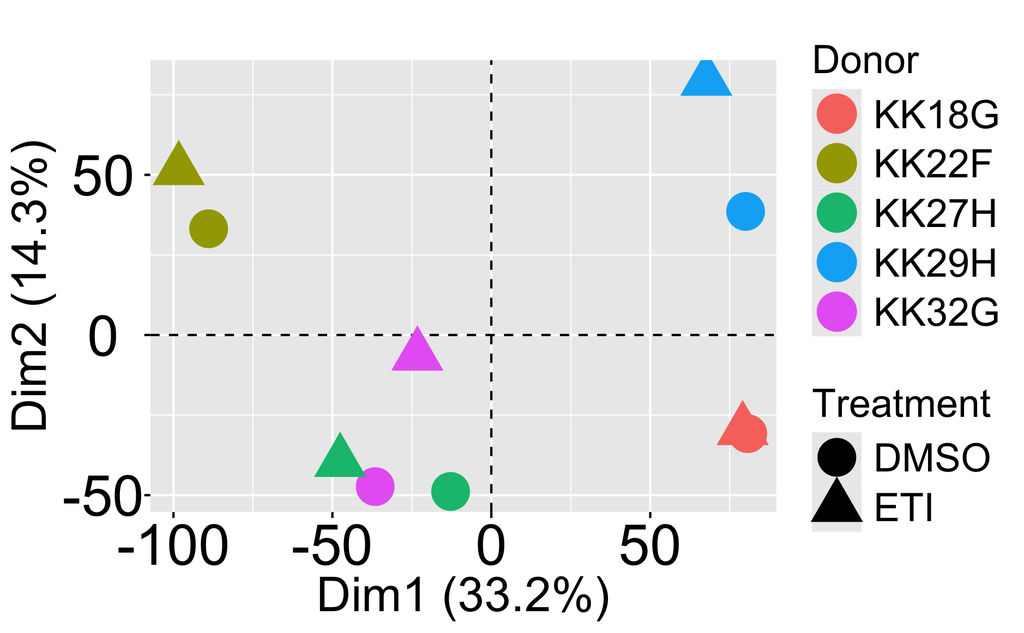

```r
Donor = factor(ETI_meta$Donor)
Treatment = factor(ETI_meta$Rx)



my_theme <- theme(axis.text = element_text(size = 26),
                  axis.title = element_text(size = 22),
                  legend.text = element_text(size = 18),
                  legend.title = element_text(size = 18))

fviz_pca_ind(pca_resETI, label = "none", habillage = "none",
             geom="text",  pointsize = 6, invisible="quali",
             title = "", ggtheme = my_theme) +
  geom_point(aes(col=Donor, shape=Treatment), size=8)

ggsave("ETI.PCA.pdf", width = 9, height = 5)
```

### Differential Gene Expression

```r
fitETI <- glmFit(DGE.ETI, design.ETI)
colnames(fitETI$coefficients)
```

```
[1] "(Intercept)"         "ETI_meta$DonorKK22F" "ETI_meta$DonorKK27H"
[4] "ETI_meta$DonorKK29H" "ETI_meta$DonorKK32G" "ETI_meta$RxETI"
```

```r
#
# [1] "(Intercept)"         "ETI_meta$DonorKK22F"
# [3] "ETI_meta$DonorKK27H" "ETI_meta$DonorKK29H"
# [5] "ETI_meta$DonorKK32G" "ETI_meta$RxETI"

lrtETI <- glmLRT(fitETI, coef = "ETI_meta$RxETI") #specify the comparison of interest
topTags(lrtETI , n=40)
```

```
Coefficient:  ETI_meta$RxETI
```

|  | Ensembl.ID | Gene.Name | logFC | logCPM | LR | PValue | FDR |
| --- | --- | --- | --- | --- | --- | --- | --- |
| 56570 | ENSG00000197446 | CYP2F1 | -4.0050221 | 2.997203 | 41.13121 | 1.423451e-10 | 2.175461e-06 |
| 27077 | ENSG00000164825 | DEFB1 | 1.1086012 | 7.142946 | 32.02665 | 1.520723e-08 | 1.162061e-04 |
| 59143 | ENSG00000100292 | HMOX1 | -1.2810029 | 5.359892 | 28.05272 | 1.180551e-07 | 6.014119e-04 |
| 31954 | ENSG00000110628 | SLC22A18 | 1.0872330 | 4.479093 | 24.87160 | 6.127848e-07 | 2.341297e-03 |
| 49773 | ENSG00000189343 | RPS2P46 | 1.4989939 | 5.643757 | 24.21362 | 8.622055e-07 | 2.427496e-03 |
| 60548 | ENSG00000212907 | MT-ND4L | 0.7627672 | 10.988034 | 24.02078 | 9.530182e-07 | 2.427496e-03 |
| 34438 | ENSG00000166670 | MMP10 | -0.8512846 | 6.955182 | 22.88564 | 1.719315e-06 | 3.753757e-03 |
| 36309 | ENSG00000107742 | SPOCK2 | -1.1526523 | 4.205028 | 19.51499 | 9.981310e-06 | 1.906805e-02 |
| 35 | ENSG00000225630 | MTND2P28 | 1.4830913 | 9.056348 | 18.79352 | 1.456616e-05 | 2.473495e-02 |
| 34442 | ENSG00000262406 | MMP12 | -0.9748769 | 4.869835 | 18.23049 | 1.957204e-05 | 2.991195e-02 |

[output cut: 30 more lines]

```r
summary(decideTestsDGE(lrtETI, adjust.method = "fdr")) # 5 down, 6 up
```

```
       ETI_meta$RxETI
Down                5
NotSig          15272
Up                  6
```

```r
Results.ETI <- as.data.frame(topTags(lrtETI, n = dim(DGE.ETI)[1]))

# This is what was used for Ingenuity, but I changed the name to Results.CFeti.csv

write.csv(Results.ETI , file = "Results.ETI.csv", row.names = FALSE)
```

### CFTR was not itself affected”

```r
Results.ETI[Results.ETI$Gene.Name == "CFTR",c("logFC", "PValue")]
```

|  | logFC | PValue |
| --- | --- | --- |
| 23691 | -0.2734791 | 0.4406043 |

### Visualize as volcano plot

Figure 1B

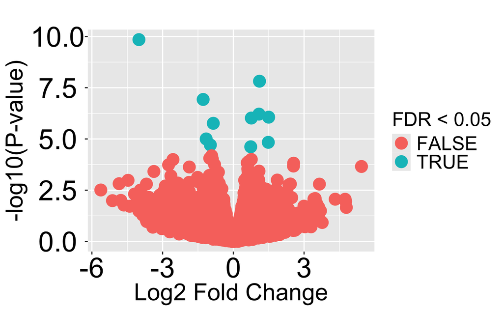

```r
my_theme <- theme(axis.text = element_text(size = 26),
                  axis.title = element_text(size = 22),
                  legend.text = element_text(size = 18),
                  legend.title = element_text(size = 18))
# Create the volcano plot
ggplot(Results.ETI, aes(x = logFC, y = -log10(PValue))) +
  geom_point(aes(color = FDR < 0.05), size = 5) +  # Color by significance
  labs(x = "Log2 Fold Change", y = "-log10(P-value)", title = "") +
  # Add significance threshold lines (optional)
  # geom_hline(yintercept = -log10(0.05), linetype = "dashed", color = "red") +
  theme_set(my_theme)

ggsave("ETI.Volcano.pdf",   width = 9, height = 5)
```

### Ingenuity

The Canonical Pathways tab displays the most significant Canonical Pathways across the entire dataset and across multiple datasets when you are reviewing a Comparison Analysis. IPA uses the p-value of overlap, calculated using the right-tailed Fisher’s Exact Test, to identify significant pathways. The significance indicates the probability of association of molecules from your dataset with the canonical pathway by random chance alone. If you would like to see Canonical Pathways that are associated with a particular network, see the Overlay Canonical Pathways section.

#### Write out results

```r
write.csv(Results.ETI , file = "Results.ETI.csv", row.names = FALSE)
write.csv(Results.ETI[Results.ETI$FDR < .05,], file = "ETI.Gene.FDR.csv")
```

#### Read back in Ingenuity-annotated data

```r
IngenuityAnnot <- read.delim("Results.ETI.Ingenuity.txt", skip = 1)
sum(IngenuityAnnot$Symbol == "H2BC9")
```

```
[1] 1
```

### Table 1: FDR < .05 (Annotated)

```r
ETI.Results.Annot <- merge(Results.ETI, IngenuityAnnot,
                           by.x =  "Ensembl.ID",
                           by.y = "ID")

#sum(ETI.Results.Annot$Symbol == "H2BC9")

Table.1 <- ETI.Results.Annot[ETI.Results.Annot$FDR < .05, c("Gene.Name",
                                                            "Entrez.Gene.Name",
                                                            "logFC",
                                                            "PValue",
                                                            "FDR")]

colnames(Table.1) <- c("Symbol", "Entrez gene name", "log2FC", "PValue", "FDR")

Table.1$log2FC <- signif(Table.1$log2FC, 2)
Table.1$PValue <- signif(Table.1$PValue, 2)
Table.1$FDR <- signif(Table.1$FDR, 2)

Table.1 <- Table.1[order(Table.1$log2FC),]

write.csv(Table.1, file = "Table1.csv", row.names = FALSE)
```

### Table 2: Canonnical Pathways (FC > 1; P < .05)

288 genes were analysis ready in that they had an absolute log2 fold change greater than 1 and P < .05 based on edgeR analysis.

```r
IngenuityCanPath <- read.delim("CanPathTable.txt", skip = 2)

IngenuityCanPath.Z1 <- IngenuityCanPath[ !is.na(IngenuityCanPath$z.score) &   abs(IngenuityCanPath$z.score) > 1 & 10^-IngenuityCanPath$X.log.p.value. < .05 , ]

write.csv(IngenuityCanPath.Z1 , file = "CanPathTable.csv", row.names = FALSE)

PathToKeep <- setdiff(IngenuityCanPath.Z1$Ingenuity.Canonical.Pathways, c("IL-10 Signaling",
                                                            "Th1 Pathway"))
IngenuityCanPath.Z1.Airway <- IngenuityCanPath.Z1[IngenuityCanPath.Z1$Ingenuity.Canonical.Pathways %in% PathToKeep,]
```

#### Heat map of fold changes of pathway genes

```r
PathGenesLists <- lapply(IngenuityCanPath.Z1.Airway$Molecules, function (l){
  unlist(strsplit(l,","))
})
names(PathGenesLists) <- IngenuityCanPath.Z1.Airway$Ingenuity.Canonical.Pathways

PathGenes <- unique(unlist(lapply(PathGenesLists, function (l){
  unlist(strsplit(l,","))
})))

PathPaths <- c("MHC class II antigen presentation" ,
               "Xenobiotic Metabolism CAR Signaling Pathway",
               "DNA Replication Pre-Initiation",
               "Synthesis of DNA",
               "Mitotic G2-G2/M phases",
               "Mitotic G1 phase and G1/S transition",
               "Senescence-Associated Secretory Phenotype (SASP)"
               )

PathGenes <- c(sort(c("IL6", "HLA-DPB1", "HLA-DMB", "KIF2C", "CTSV")),
                   sort(c("CYP1A2", "CHST2", "CHST4", "HS6ST2")),
                   sort(c("CCNA2", "CDC6", "CDC26", "CDT1", "MYBL2", "FBXL7",
                   "PPP2R3B", "CEP131", "H2BC9")))

# OK, now we have a matrix

PathMat <- matrix(ncol = length(PathGenes),
                  nrow = length(PathPaths),
                  dimnames = list("Pathway"=PathPaths, "Gene" = PathGenes),
                  data = 0)

foldChanges <- lapply(PathGenes, function (g){
  IngenuityAnnot[IngenuityAnnot$Symbol == g, "Expr.Log.Ratio"]
})

names(foldChanges) <- PathGenes
```

#### Fill in the matrix

```r
lapply(names(PathGenesLists), function(l){
  PathMat[l, unlist(PathGenesLists[[l]])] <<- unlist(foldChanges[PathGenesLists[[l]]])
})
```

```
[[1]]
 CCNA2  CDC26  H2BC9    IL6
-2.884 -2.257 -2.280 -1.575

[[2]]
  CCNA2    CDC6    CDT1   MYBL2 PPP2R3B
 -2.884  -2.315  -2.942  -2.542  -1.270

[[3]]
 CDC26   CDC6   CDT1  H2BC9
-2.257 -2.315 -2.942 -2.280

[[4]]
 CCNA2  CDC26   CDC6   CDT1
-2.884 -2.257 -2.315 -2.942

[[5]]
    CTSV  HLA-DMB HLA-DPB1    KIF2C
  -1.084   -2.119   -2.587   -3.341

[[6]]
  CHST2   CHST4  CYP1A2  HS6ST2 PPP2R3B
 -1.132  -1.449  -3.478  -1.146  -1.270

[[7]]
  CCNA2  CEP131   FBXL7   MYBL2 PPP2R3B
 -2.884  -1.347  -1.335  -2.542  -1.270
```

#### Heatmap

```r
# BiocManager::install("ComplexHeatmap")
# BiocManager::install("circlize")

library(circlize)
col_fun = colorRamp2(c(3, 0, -3), c("blue", "white", "red"))

library(ComplexHeatmap)
hm <- Heatmap(PathMat,
              show_heatmap_legend = FALSE,
              cluster_columns = FALSE, cluster_rows = FALSE,
              col = col_fun,
              row_names_gp = gpar(fontsize = 16),
              column_names_gp = gpar(fontsize = 16))

lgd = Legend(col_fun = col_fun, title = "ETI Response (log2)",
             direction = "horizontal",
             title_gp = gpar(fontsize = 16),
             labels_gp = gpar(fontsize = 14))


pdf(file="IngPathMap.pdf", width=15)

draw (hm, padding = unit(c(.25, .25, .25, 3.5), "in"))
draw(lgd, x = unit(12, "in"), y = unit(1, "in"))
```

```r
dev.off()
```

### Gene annotations and edgeR results for genes in IPA pathways

```r
sum(ETI.Results.Annot$Gene.Name == "H2BC9")
```

```
[1] 0
```

```r
Table.2.new <- ETI.Results.Annot[ETI.Results.Annot$Symbol %in% PathGenes,
                                 c( "Symbol",
                                    "Entrez.Gene.Name",
                                    "logFC",
                                    "PValue")]


colnames(Table.2.new) <- c("Symbol", "Entrez gene name", "log2FC", "PValue")

Table.2.new$log2FC <- signif(Table.2.new$log2FC, 2)
Table.2.new$PValue <- signif(Table.2.new$PValue, 2)

rownames(Table.2.new) <- Table.2.new$Symbol

Table.2.new <- Table.2.new[PathGenes,]

write.csv(Table.2.new, file = "Table.2.new.csv", row.names = FALSE)
```

### Grouping genes on clustered pathways together

```r
sort(unique(c(PathGenesLists$`IL-10 Signaling`,
PathGenesLists$`Th1 Pathway`,
PathGenesLists$`MHC class II antigen presentation`)))
```

```
[1] "CTSV"     "HLA-DMB"  "HLA-DPB1" "KIF2C"
```

```r
PathGenesLists$`Xenobiotic Metabolism CAR Signaling Pathway`
```

```
[1] "CHST2"   "CHST4"   "CYP1A2"  "HS6ST2"  "PPP2R3B"
```

```r
sort(unique(c(PathGenesLists$`Senescence-Associated Secretory Phenotype (SASP)`,
PathGenesLists$`Mitotic G1 phase and G1/S transition`,
PathGenesLists$`DNA Replication Pre-Initiation`,
PathGenesLists$`Synthesis of DNA`,
PathGenesLists$`Mitotic G2-G2/M phases`)))
```

```
 [1] "CCNA2"   "CDC26"   "CDC6"    "CDT1"    "CEP131"  "FBXL7"   "H2BC9"   "IL6"
 [9] "MYBL2"   "PPP2R3B"
```

### PCR Data

```r
# Read in CT values

CTmat <- read.csv("CTmat.csv")
References <- c("GAPDH", "GUSB", "HPRT1", "HSP90AB", "UBC")

library(ctrlGene)

geNormResult2 <- geNorm2(CTmat[, References], ctVal = TRUE)

geNormResult2
```

| Genes | Avg.M |
| --- | --- |
| UBC | 0.5251885 |
| GUSB | 0.4476367 |
| HPRT1 | 0.3090206 |
| GAPDH | 0.2273092 |
| HSP90AB | NA |

```r
d.All <- read.csv("CTmat.csv")

d.All$Donor <- substr(d.All$X, 1,5)
d.All$Modulator <- substr(d.All$X, 7,10)

Target.Names <- c("DEFB1", "HMOX1", "IL1B", "MMP10",  "MMP12",  "TNF")

d.All$Ref = apply(CTmat[, c("HSP90AB", "GAPDH",  "HPRT1")], 1, mean )
```

### The statistics

```r
library(lme4)
# install.packages("lmerTest")
library(lmerTest)

# Define the base formula template
base_formula <- "DEFB1 ~ Modulator + Ref + (1|Donor)"

# List to store the generated formulas
all_formulas <- vector(length = length(Target.Names), mode = "character")

for (i in seq_along(Target.Names)) {
  # Replace "DEFB1" with the current column name in the formula template
  all_formulas[i] <- gsub("DEFB1", Target.Names[i], base_formula)
}

lmer(TNF ~ Modulator + Ref + (1|Donor), data = d.All)
```

```
Linear mixed model fit by REML ['lmerModLmerTest']
Formula: TNF ~ Modulator + Ref + (1 | Donor)
   Data: d.All
REML criterion at convergence: 26.2872
Random effects:
 Groups   Name        Std.Dev.
 Donor    (Intercept) 2.093
 Residual             0.468
Number of obs: 10, groups:  Donor, 5
Fixed Effects:
 (Intercept)  ModulatorETI           Ref
   25.330713     -0.002963      0.084725
```

```r
MixedModels <- lapply(all_formulas, function (f) {
  coefficients(summary(lmer(formula = f, data = d.All)))
})

names(MixedModels) <- Target.Names
```

### Statistics

```r
ETI.Estimates <- as.data.frame(lapply (MixedModels, function (m){
  m["ModulatorETI",]
}))


ETI.Estimates.Flip <- as.data.frame(t(ETI.Estimates))

ETI.Estimates.Flip$Gene.Name = rownames(ETI.Estimates.Flip)

# Adjust p values where we had a prior hypothesis that was correct. We hypothesized that DEFB1 would increase, meaning that

RNA.Seq.concordance <-  merge(ETI.Results.Annot,
                            ETI.Estimates.Flip,
                            by = "Gene.Name" )

RNA.Seq.concordance <- RNA.Seq.concordance [, c("Gene.Name",        "logFC", "FDR", "Estimate", "Pr(>|t|)" ) ]

RNA.Seq.concordance$Concordant <- sign(RNA.Seq.concordance$logFC) != sign(RNA.Seq.concordance$Estimate)

RNA.Seq.concordance$P <- RNA.Seq.concordance$`Pr(>|t|)`

RNA.Seq.concordance$P[RNA.Seq.concordance$Concordant] <-
  RNA.Seq.concordance$P[RNA.Seq.concordance$Concordant]/2

write.csv(RNA.Seq.concordance, file = "RNA.Seq.concordance.csv")
```

### Print out stats

```r
ETI.Estimates
```

|  | DEFB1 | HMOX1 | IL1B | MMP10 | MMP12 | TNF |
| --- | --- | --- | --- | --- | --- | --- |
| Estimate | -0.79676140 | 0.44292732 | -0.1276444 | 0.94071322 | 1.17568858 | -0.002962968 |
| Std. Error | 0.19598695 | 0.09780048 | 0.4543735 | 0.18845741 | 0.48445058 | 0.298277029 |
| df | 3.54654211 | 2.88712312 | 3.9019893 | 2.25016755 | 3.12156931 | 3.082919544 |
| t value | -4.06537983 | 4.52888719 | -0.2809238 | 4.99164887 | 2.42684933 | -0.009933612 |
| Pr(>\|t\|) | 0.01942013 | 0.02185871 | 0.7930331 | 0.02962153 | 0.09025452 | 0.992682272 |

```r
NA
```

### Range of P for DEFB1, MMP10 MMP12 HMOX1

```r
round(ETI.Estimates['Pr(>|t|)',],2)
```

|  | DEFB1 | HMOX1 | IL1B | MMP10 | MMP12 | TNF |
| --- | --- | --- | --- | --- | --- | --- |
| Pr(>\|t\|) | 0.02 | 0.02 | 0.79 | 0.03 | 0.09 | 0.99 |

### Graphics

Plot

```r
lapply(Target.Names, function (t) {
  F = as.data.frame(d.All.L[d.All.L$Gene %in% c(t, "Ref"), ])
  average_data <- average_by_modulator(F)
  average_data$Donor = "Mean"
  average_data$Gene <- factor(average_data$Gene, levels = c(t, "Ref"))

  # how to select
  ggplot(F[F$Gene == t,], aes(x = Modulator, y = CT, color = Donor, shape = Gene)) +
  # Group by Gene and Donor for connecting lines
  geom_line(aes(group = interaction(Gene, Donor)),
            linetype = "solid", linewidth = 1.5) +
  geom_point(size=4) +
  geom_point(data = average_data, aes(x=Modulator,y=mean_CT, shape = Gene,   group=Donor), inherit.aes = FALSE, size=5, show.legend = FALSE) +
  geom_line(data = average_data, aes(x=Modulator,y=mean_CT, group = interaction(Gene, Donor)), inherit.aes = FALSE,
            linewidth=1, linetype=2) +
  ggtitle(t) +
  theme_set(my_theme)
  ggsave(paste(t, "Panel.pdf", sep = '.'), width = 4, height = 4.5)
})
```

```
[[1]]
[1] "DEFB1.Panel.pdf"

[[2]]
[1] "HMOX1.Panel.pdf"

[[3]]
[1] "IL1B.Panel.pdf"

[[4]]
[1] "MMP10.Panel.pdf"

[[5]]
[1] "MMP12.Panel.pdf"

[[6]]
[1] "TNF.Panel.pdf"
```

### Classic delta delta CT

Note that these estimtes differ a bit from the estimates developed by the linear model

```r
refMean <- tapply(d.All$Ref, d.All$Modulator, FUN = mean)

DD.CT <- lapply(Target.Names, function (t){
  m = tapply(d.All[,t], d.All$Modulator, FUN = mean)
  mNorm <- m - refMean
  mNorm["ETI"] - mNorm["DMSO"]
})

names(DD.CT) <- Target.Names

round(unlist(DD.CT), 2)
```

```
DEFB1.ETI HMOX1.ETI  IL1B.ETI MMP10.ETI MMP12.ETI   TNF.ETI
    -0.85      0.45     -0.24      0.92      1.19     -0.05
```

### ELISA

We have more cytokine data from the basolateral side, and that’s what we are going to use for this paper.

```r
Paired_BD1 <- read.csv("Amanda/Xpt/BD1apical.csv", header =T)
Paired_IL6 <- read.csv("Amanda/Xpt/IL6apical.csv", header =T)
Paired_GCSF_B <- read.csv("Amanda/Xpt/Basal_GCSF.csv", header =T)
Paired_IL6_B <- read.csv("Amanda/Xpt/Basal_IL6.csv", header =T)
Paired_IL8_B <- read.csv("Amanda/Xpt/Basal_IL8.csv", header =T)
Paired_MCP1_B <- read.csv("Amanda/Xpt/Basal_MCP1.csv", header =T)
```

```r
load("~/Documents/PCR/Correlation.RData")

E.Data <- ls(pattern="Paired")
E.Data <- E.Data[grep("df$", E.Data, invert = TRUE)]

E.Measurements <- lapply(E.Data, function (var.name){
  eval(parse(text = var.name))
} )

names(E.Measurements) <- E.Data

# add log2 columns to each

lapply(names(E.Measurements), function (n){
  E.Measurements[[n]]$log2 <<- log2(E.Measurements[[n]]$Measurements)
} )
```

```
[[1]]
 [1] 12.435291 11.395518 11.962255 10.522236  7.934894 12.875294 11.205334
 [8] 12.174794 11.638811  8.037625

[[2]]
 [1] 11.608609  9.531912 11.188138 11.428277  9.199673 12.362302  9.874072
 [8] 12.714295 11.428274  9.627453

[[3]]
 [1] 13.232786 11.947966 11.466409 12.468302 10.481112 11.876985 11.745779
 [8] 11.838040 12.475719  9.257618

[[4]]
 [1] 11.873367 11.304338  8.795017 11.163449  9.032271 12.220874 11.718591
 [8]  8.525147 10.115075  9.545203

[[5]]
 [1] 13.89172 13.87958 14.21072 14.71530 14.31904 14.69956 14.00152 14.98941
 [9] 14.07904 15.49014

[[6]]
 [1] 10.512013  9.696586  9.776230 10.740284  9.335983 10.768625  9.728180
 [8]  9.703016 10.394622  9.369656
```

### ELISA log2 measurements

```r
ELISA.FC <- lapply(names(E.Measurements), function (x){

  m <- E.Measurements[[x]]
  Donor <- m$ID[m$group == "MC ETI"]
  log2FC <- m$log2[m$group == "MC ETI"]  - m$log2[m$group == "MC DMSO"]
  Analyte <- sub("Paired_", "", x)
  data.frame("Analyte" = rep(Analyte, length(Donor)),
                                "Donor" = Donor,
                                "log2FC" = log2FC)
} )

ELISA.FC.Frame <- do.call(rbind, ELISA.FC)
ELISA.FC.Frame$Donor[ELISA.FC.Frame$Donor == "K18G"] <- "KK18G"
ELISA.FC.Frame$Cytokine <- sub("_B", "", ELISA.FC.Frame$Analyte)
ELISA.FC.Frame$Side <- "Apical"
ELISA.FC.Frame$Side[grep("_B", ELISA.FC.Frame$Analyte)] <- "Basolateral"

# fix cytokine names

ELISA.FC.Frame$Cytokine[ELISA.FC.Frame$Cytokine == "IL6"] <- "IL-6"
ELISA.FC.Frame$Cytokine[ELISA.FC.Frame$Cytokine == "IL8"] <- "IL-8"
ELISA.FC.Frame$Cytokine[ELISA.FC.Frame$Cytokine == "BD1"] <- "hBD-1"
ELISA.FC.Frame$Cytokine[ELISA.FC.Frame$Cytokine == "GCSF"] <- "G-CSF"
```

#### Plot ETI Effects

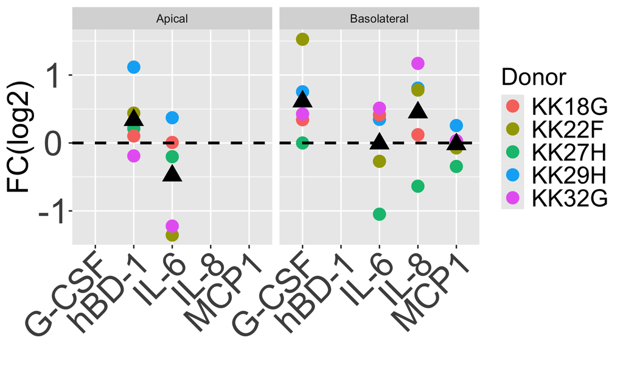

### Log2 cytokine changes into ordinary terms

Variability

[output not shown]

### Elisa Stats for BD1

Here we have a prior hypothesis.

```r
t.test (ELISA.FC.Frame$log2FC[ELISA.FC.Frame$Analyte == "BD1"],
        alternative = "greater")
```

```
    One Sample t-test

data:  ELISA.FC.Frame$log2FC[ELISA.FC.Frame$Analyte == "BD1"]
t = 1.5299, df = 4, p-value = 0.1004
alternative hypothesis: true mean is greater than 0
95 percent confidence interval:
 -0.1323437        Inf
sample estimates:
mean of x
0.3363332
```

### Create RNA-seq fold changes for each donor based on CPM

```r
identical(ETI_meta$Sample, colnames(CPM.ETI.Annot)[colnames(CPM.ETI.Annot) %in% ETI_meta$Sample] ) # Good
```

```
[1] TRUE
```

#### Create a gene symbol data frame

The original data was by Ensemble gene ID, leading to instances of the same gene symbol in a few cases. This multi-matching would create a problem for comparisons between cytokine and transcriptomic responses.

```r
# throw out genes with more than 1 row

Dupes <- CPM.ETI.Annot$Gene.Name[which(duplicated(CPM.ETI.Annot$Gene.Name))] # who cares
UniqueGenes <- CPM.ETI.Annot$Gene.Name[which(!duplicated(CPM.ETI.Annot$Gene.Name)) ]

CPM.ETI.Effect.U <- CPM.ETI.Effect[which(!duplicated(CPM.ETI.Annot$Gene.Name)),]

rownames(CPM.ETI.Effect.U) <- CPM.ETI.Annot$Gene.Name[which(!duplicated(CPM.ETI.Annot$Gene.Name)) ]

RNA.FC <-  data.frame(t(CPM.ETI.Effect.U))


write.csv(RNA.FC, file = "RNA.FC.csv")


# RNA.FC.Targets <- RNA.FC[,Targets]

# colnames(RNA.FC.Targets) <- paste(colnames(RNA.FC.Targets), "FC", sep = '.')
```

### Map Gene Expression Results onto Cytokine Results,

```r
identical(ELISA.FC.Frame$Donor[ELISA.FC.Frame$Cytokine == "hBD-1"],
row.names(RNA.FC) )
```

```
[1] TRUE
```

### Do gene and protein level responses correlate?

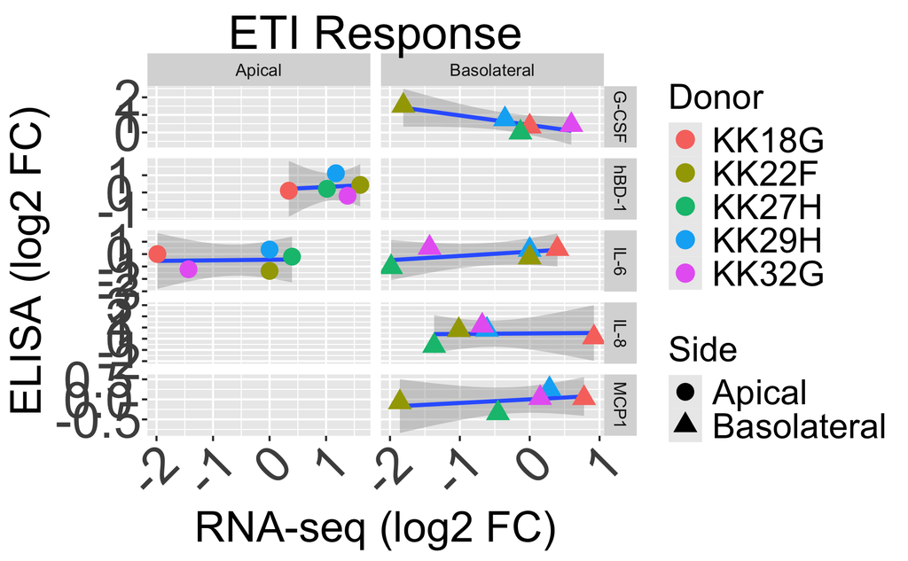

```r
my_theme <- theme(axis.text.x = element_text(size = 26),
                  axis.text.y = element_text(size = 26),
                  axis.title = element_text(size = 22),
                  legend.text = element_text(size = 18),
                  legend.title = element_text(size = 18),
                  plot.title = element_text(size = 24),
                  legend.position = "right")
p <- ggplot(ELISA.FC.Frame , aes(y = log2FC, x = RNA.FC, shape = Side)) +
  stat_smooth(method = "lm", formula= y ~x)  + facet_grid(Cytokine ~ Side, scales='free') +
  geom_point(aes(y = log2FC, x = RNA.FC, colour = Donor), size = 4) +
  labs(x = "RNA-seq (log2 FC)",  y = "ELISA (log2 FC)", title = "ETI Response")

p + theme_set(my_theme)
ggsave("RNA.ELISA.pdf", height = 20, width = 10)
```

### Do gene and protein level responses correlate (statistics)

```r
RNA.ELISA.cor <- lapply(unique(ELISA.FC.Frame$Analyte), function (l){
  A = ELISA.FC.Frame[ELISA.FC.Frame$Analyte == l,]
  cor.test(A$log2FC,A$RNA.FC, alternative = "greater")
})

names(RNA.ELISA.cor) <- unique(ELISA.FC.Frame$Analyte)
```

#### Statistics for all cytokines using RNA-seq as prior

To be consistent with edgeR RNA-seq results, one should use ETI.Results.Annot log fold changes

```r
2^ELISA.FC.Frame[ELISA.FC.Frame$Donor == "KK22F" &
                ELISA.FC.Frame$Analyte == "GCSF_B", "log2FC"] * 100
```

```
[1] 288.0177
```

### Assumption free statistics

```r
Cytokine.T.tests.NoPrior <- lapply(unique(ELISA.FC.Frame$Analyte), function (a){
  A = ELISA.FC.Frame[ELISA.FC.Frame$Analyte == a,]
  t.test(A$log2FC, alternative = "two.sided")
})

names(Cytokine.T.tests.NoPrior) <- unique(ELISA.FC.Frame$Analyte)

Cytokine.T.tests.NoPrior
```

```
$BD1

    One Sample t-test

data:  A$log2FC
t = 1.5299, df = 4, p-value = 0.2008
alternative hypothesis: true mean is not equal to 0
95 percent confidence interval:
 -0.2740557  0.9467220
sample estimates:
mean of x
0.3363332


$GCSF_B

    One Sample t-test

data:  A$log2FC
t = 2.3591, df = 4, p-value = 0.07774
alternative hypothesis: true mean is not equal to 0
95 percent confidence interval:
 -0.1079128  1.3278276
sample estimates:
mean of x
0.6099574


$IL6

    One Sample t-test

data:  A$log2FC
t = -1.3988, df = 4, p-value = 0.2344
alternative hypothesis: true mean is not equal to 0
95 percent confidence interval:
 -1.4341951  0.4732212
sample estimates:
mean of x
-0.480487
```

[output cut: 27 more lines]

```
0.4486601


$MCP1_B

    One Sample t-test

data:  A$log2FC
t = -0.19854, df = 4, p-value = 0.8523
alternative hypothesis: true mean is not equal to 0
95 percent confidence interval:
 -0.2906836  0.2518855
sample estimates:
  mean of x
-0.01939904
```

### Checking Kiyoshi’s package versions

R & D Systems #DY208, #DY201, #DY210

```r
library(drc)
```

### How many donors would be required to achieve IL-6 significance

```r
library(pwr)

# d is mean difference divided by sd
# Our difference was .048

m = mean(ELISA.FC.Frame[ELISA.FC.Frame$Analyte == "IL6", "log2FC"])
sd =  sd(ELISA.FC.Frame[ELISA.FC.Frame$Analyte == "IL6", "log2FC"])
d = m/sd
P = pwr.t.test(n = NULL, d = abs(d), sig.level = 0.05, power = 0.8, type = "one.sample", alternative = "greater")
```

### Effect of ETI on Chloride Channel

Donor KK22F DMSO: 0.52 0.92 ETI: 4.49 3.38

Donor KK29H DMSO: 1.83 1.88 ETI: 3.95 5.68

Donor KK32G: DMSO: 1.29 ETI: 6.29

```r
Cl <- data.frame("Donor" = rep(c("KK22F", "KK29H", "KK32G"), each = 2),
                 "Rx" = rep(c("DMSO", "ETI"), 3),
                 "i" = c(mean(c(0.52, 0.92)),
                         mean(c(4.49, 3.38)),
                         mean(c(1.83, 1.88)),
                         mean(c(3.95, 5.68)),
                         mean(c(1.29)),
                         mean(c(6.29))))
```

y axis is Isc(uA/cm2)

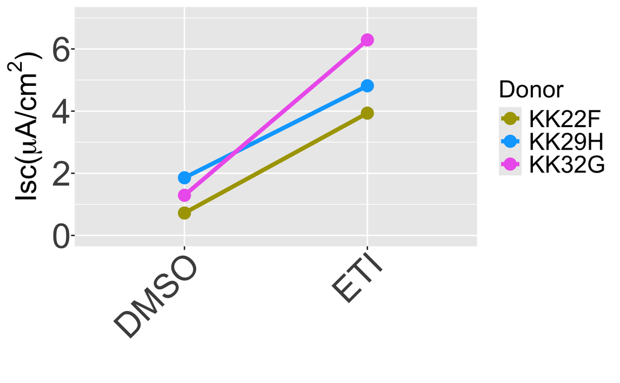

```r
library(ggplot2)
ggplot(Cl, aes(x = Rx, y = i, color = Donor)) +
  # Group by Gene and Donor for connecting lines
  geom_line(aes(group = Donor),
            linetype = "solid", linewidth = 1.5) +
  geom_point(size=4) +
  scale_color_manual(values = c("#ABA300", "#00A9FF", "#ED68ED")) +
  ylim(0,7) +
  ylab(expression(paste("Isc(", mu, "A/cm"^{2}, ")", sep = ""))) +
  xlab("") +
  theme_set(my_theme)
  ggsave("Ussings.pdf")
```

```r
library(lme4)
library(lmerTest)

summary(lmer(i ~ Rx + (1|Donor), data = Cl))
```

```
Linear mixed model fit by REML. t-tests use Satterthwaite's method [lmerModLmerTest
]
Formula: i ~ Rx + (1 | Donor)
   Data: Cl

REML criterion at convergence: 12.8

Scaled residuals:
    Min      1Q  Median      3Q     Max
-0.9021 -0.3614 -0.3053  0.3986  1.2595

Random effects:
 Groups   Name        Variance Std.Dev.
 Donor    (Intercept) 0.2513   0.5013
 Residual             0.6177   0.7860
Number of obs: 6, groups:  Donor, 3

Fixed effects:
            Estimate Std. Error     df t value Pr(>|t|)
(Intercept)   1.2883     0.5382 3.6913   2.394   0.0803 .
RxETI         3.7250     0.6417 2.0000   5.805   0.0284 *
---
Signif. codes:  0 ‘***’ 0.001 ‘**’ 0.01 ‘*’ 0.05 ‘.’ 0.1 ‘ ’ 1

Correlation of Fixed Effects:
      (Intr)
RxETI -0.596
```

```r
IscRes <- coef(summary(lmer(i ~ Rx + (1|Donor), data = Cl)))
IscRes["RxETI", "Estimate"]/IscRes["(Intercept)", "Estimate"]
```

```
[1] 2.891332
```